# Chapter 2 - Hands-On Machine Learning with SciKit-Learn & TensorFlow

The task that this chapter presents is just doing a simple regression test on housing data to try predict prices. The audience for this notebook is primarily myself.

## Get the Data

Before we do anything too exciting, I'm just going to put all my imports into a single cell.

```python
%matplotlib inline
import os
import tarfile
from six.moves import urllib
import pandas as pd
import matplotlib.pyplot as plt
import numpy as np
from sklearn.model_selection import train_test_split, StratifiedShuffleSplit
from pandas.plotting import scatter_matrix
from sklearn.impute import SimpleImputer
from sklearn.preprocessing import OrdinalEncoder, OneHotEncoder, StandardScaler
from sklearn.base import BaseEstimator, TransformerMixin
from sklearn.pipeline import Pipeline
from sklearn.compose import ColumnTransformer
from sklearn.linear_model import LinearRegression
from sklearn.metrics import mean_squared_error
from sklearn.tree import DecisionTreeRegressor
from sklearn.model_selection import cross_val_score, GridSearchCV
from sklearn.ensemble import RandomForestRegressor
```

Now I'll write a quick little function to fetch the data and save it to a known location.

```python
DOWNLOAD_ROOT = "https://raw.githubusercontent.com/ageron/handson-ml/master/"
HOUSING_PATH = os.path.join("datasets", "housing")
HOUSING_URL = DOWNLOAD_ROOT + "datasets/housing/housing.tgz"

def fetch_housing_data(housing_url=HOUSING_URL, housing_path=HOUSING_PATH):
  if not os.path.isdir(housing_path):
    os.makedirs(housing_path)
  tgz_path = os.path.join(housing_path, "housing.tgz")
  urllib.request.urlretrieve(housing_url, tgz_path)
  housing_tgz = tarfile.open(tgz_path)
  housing_tgz.extractall(path=housing_path)
  housing_tgz.close()

fetch_housing_data()
```

Next we'll load the data into a pandas DataFrame just so it's easier to work with and so we can take a little peak into it.

```python
def load_housing_data(housing_path=HOUSING_PATH):
  csv_path = os.path.join(housing_path, "housing.csv")
  return pd.read_csv(csv_path)

housing = load_housing_data()
housing.head()
```

|  | longitude | latitude | housing_median_age | total_rooms | total_bedrooms | population | households | median_income | median_house_value | ocean_proximity |
| --- | --- | --- | --- | --- | --- | --- | --- | --- | --- | --- |
| 0 | -122.23 | 37.88 | 41.0 | 880.0 | 129.0 | 322.0 | 126.0 | 8.3252 | 452600.0 | NEAR BAY |
| 1 | -122.22 | 37.86 | 21.0 | 7099.0 | 1106.0 | 2401.0 | 1138.0 | 8.3014 | 358500.0 | NEAR BAY |
| 2 | -122.24 | 37.85 | 52.0 | 1467.0 | 190.0 | 496.0 | 177.0 | 7.2574 | 352100.0 | NEAR BAY |
| 3 | -122.25 | 37.85 | 52.0 | 1274.0 | 235.0 | 558.0 | 219.0 | 5.6431 | 341300.0 | NEAR BAY |
| 4 | -122.25 | 37.85 | 52.0 | 1627.0 | 280.0 | 565.0 | 259.0 | 3.8462 | 342200.0 | NEAR BAY |

Now is probably a fine time to explain what we're seeing here. Each row in this dataset represents a housing district. This is basically data from the US census where a district is a parcel of houses. I believe that this is the mose granular view of this data tat the census collects. The columns here seem to be somewhat self-explanatory, but let's get a bit more information about what each holds.

```python
housing.info()
```

```
<class 'pandas.core.frame.DataFrame'>
RangeIndex: 20640 entries, 0 to 20639
Data columns (total 10 columns):
longitude             20640 non-null float64
latitude              20640 non-null float64
housing_median_age    20640 non-null float64
total_rooms           20640 non-null float64
total_bedrooms        20433 non-null float64
population            20640 non-null float64
households            20640 non-null float64
median_income         20640 non-null float64
median_house_value    20640 non-null float64
ocean_proximity       20640 non-null object
dtypes: float64(9), object(1)
memory usage: 1.6+ MB
```

This dataset has a total of 20640 entries. Most of the fields are completely saturated, except for `total_bedrooms`, which has null in just a few rows. Also, most fields are numerical except for ocean_proximity which says `object`, but it's really probably going to be a string. Let's see what values it has:

```python
housing["ocean_proximity"].value_counts()
```

```
<1H OCEAN     9136
INLAND        6551
NEAR OCEAN    2658
NEAR BAY      2290
ISLAND           5
Name: ocean_proximity, dtype: int64
```

I have a hunch that those `ISLAND` properties might be the priciest ones.

Let's take an additional peak at all the other fields, just to get a quick sense of what they look like:

```python
housing.describe()
```

|  | longitude | latitude | housing_median_age | total_rooms | total_bedrooms | population | households | median_income | median_house_value |
| --- | --- | --- | --- | --- | --- | --- | --- | --- | --- |
| count | 20640.000000 | 20640.000000 | 20640.000000 | 20640.000000 | 20433.000000 | 20640.000000 | 20640.000000 | 20640.000000 | 20640.000000 |
| mean | -119.569704 | 35.631861 | 28.639486 | 2635.763081 | 537.870553 | 1425.476744 | 499.539680 | 3.870671 | 206855.816909 |
| std | 2.003532 | 2.135952 | 12.585558 | 2181.615252 | 421.385070 | 1132.462122 | 382.329753 | 1.899822 | 115395.615874 |
| min | -124.350000 | 32.540000 | 1.000000 | 2.000000 | 1.000000 | 3.000000 | 1.000000 | 0.499900 | 14999.000000 |
| 25% | -121.800000 | 33.930000 | 18.000000 | 1447.750000 | 296.000000 | 787.000000 | 280.000000 | 2.563400 | 119600.000000 |
| 50% | -118.490000 | 34.260000 | 29.000000 | 2127.000000 | 435.000000 | 1166.000000 | 409.000000 | 3.534800 | 179700.000000 |
| 75% | -118.010000 | 37.710000 | 37.000000 | 3148.000000 | 647.000000 | 1725.000000 | 605.000000 | 4.743250 | 264725.000000 |
| max | -114.310000 | 41.950000 | 52.000000 | 39320.000000 | 6445.000000 | 35682.000000 | 6082.000000 | 15.000100 | 500001.000000 |

Again, things here are pretty self-explanatory. You can see that `total_bedrooms` has a count of 20433 instead of 20640. It's nice that null were excluded automagically. Let's give ourselves something a teensy bit more visual:

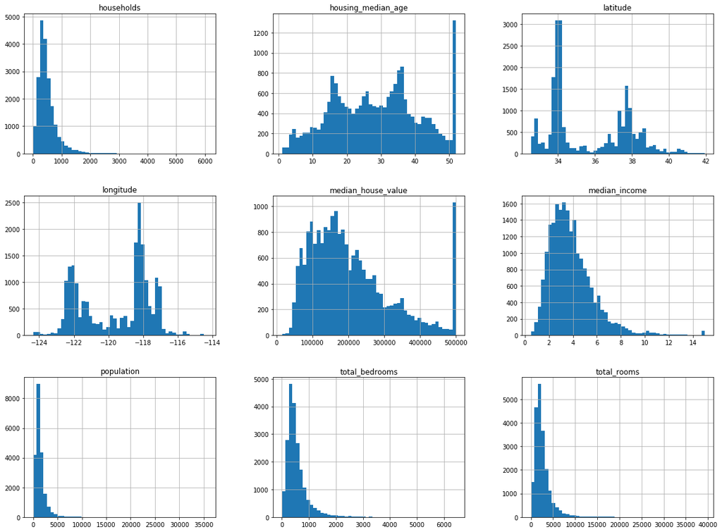

```python
housing.hist(bins=50, figsize=(20, 15))
plt.show()
```

Looking at this, there are a few little points of concern:

1. Median Income is not on a dollar scale. It's been scaled somehow. I believe that what we're looking at here is groups of 10k. So a value of 2 means 2*10k or 20,000k.
2. A few of these have big spikes of data in the last bin. This means that data was capped somehow and the last group actually represents all values greater than a certain value. E.g., in `median_house_value` we get 500,000+ as the highest item.

## Create a test set

Here is where we're going to pull out data for out test set. Technically we don't need to do it this early in the process, but if we seperate it out here and then never look at it again, then we won't get a chance to form biases about it. Below is a way that we could pull out a fully random sample of the data.

```python
train_set, test_set = train_test_split(housing, test_size=0.2, random_state=42)
```

However, with this random sample here we might introduce some sort of sample bias. We might want to make sure that the test set is equally representative of some feature of the data. For example, if we know that `median_income` is an important predictor, we might want to make sure the different values are well represented in our test set. This is call stratified sampling.

If we look back at median we can see that most values are in the 2-6 range, it's reasonable to have some fears that a random sample would accidentally over represent the importance of things outside these categories.

First we'll create an income category attribute with 5 different categories.

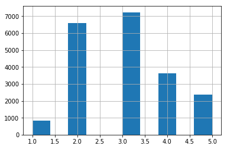

```python
housing["income_cat"] = pd.cut(housing["median_income"], bins=[0., 1.5, 3., 4.5, 6., np.inf], labels=[1, 2, 3, 4, 5])
housing["income_cat"].hist()
```

Now we can do some stratified sampling based on the income category.

```python
split = StratifiedShuffleSplit(n_splits=1, test_size=0.2, random_state=42)
for train_index, test_index in split.split(housing, housing["income_cat"]):
  strat_train_set = housing.loc[train_index]
  strat_test_set = housing.loc[test_index]

strat_test_set["income_cat"].value_counts() / len(strat_test_set)
```

```
3    0.350533
2    0.318798
4    0.176357
5    0.114583
1    0.039729
Name: income_cat, dtype: float64
```

Taking a quick look over this test set, you can see that the amount of data in each strata roughly corresponds with the distribution we saw in the original `median_income` histogram.

Let's cheekily remove the `income_cat` attribute that we added just so we don't end up training on it.

```python
for set_ in (strat_train_set, strat_test_set):
  set_.drop("income_cat", axis=1, inplace=True)
```

## Look into the data

Now we should look at the data to try to see if we can gain any insights. It's somewhat important that we just only look a the training set that we've create. Keep that test set pure.

First take a copy that we'll use here, so that we don't harm the training data.

```python
housing = strat_train_set.copy()
```

### Geographical Data

Our dataset has latitude and longitude data, so we might as well play around with it to see what we get.

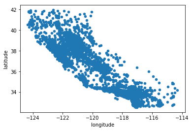

```python
housing.plot(kind="scatter", x="longitude", y="latitude")
```

Sort of looks like the state of California. How neat.

Since there are so many points on this it's kind of hard to glean any information. We can fix this by setting a quick property on that last method.

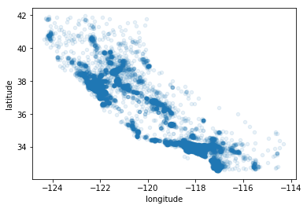

```python
housing.plot(kind="scatter", x="longitude", y="latitude", alpha=0.1)
```

Now we can much more easily see the highest density areas. Let's do something a little more complicated.

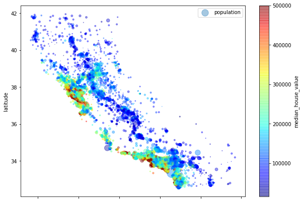

```python
housing.plot(kind="scatter", x="longitude", y="latitude", alpha=0.4, s=housing["population"]/100, label="population", figsize=(10,7),
            c="median_house_value", cmap=plt.get_cmap("jet"), colorbar=True)
plt.legend()
```

Now we've got a lot of good information in here. The size of a dot represents the population of a district, the color represents the median house value. We can gather from this that population and density have a pretty pronounced effect on price.

### Correlations

Since the dataset isn't huge, we can pretty quickly compute the Pearson's correlation between every pair of attributes.

```python
corr_matrix = housing.corr()
corr_matrix
```

|  | longitude | latitude | housing_median_age | total_rooms | total_bedrooms | population | households | median_income | median_house_value |
| --- | --- | --- | --- | --- | --- | --- | --- | --- | --- |
| longitude | 1.000000 | -0.924478 | -0.105848 | 0.048871 | 0.076598 | 0.108030 | 0.063070 | -0.019583 | -0.047432 |
| latitude | -0.924478 | 1.000000 | 0.005766 | -0.039184 | -0.072419 | -0.115222 | -0.077647 | -0.075205 | -0.142724 |
| housing_median_age | -0.105848 | 0.005766 | 1.000000 | -0.364509 | -0.325047 | -0.298710 | -0.306428 | -0.111360 | 0.114110 |
| total_rooms | 0.048871 | -0.039184 | -0.364509 | 1.000000 | 0.929379 | 0.855109 | 0.918392 | 0.200087 | 0.135097 |
| total_bedrooms | 0.076598 | -0.072419 | -0.325047 | 0.929379 | 1.000000 | 0.876320 | 0.980170 | -0.009740 | 0.047689 |
| population | 0.108030 | -0.115222 | -0.298710 | 0.855109 | 0.876320 | 1.000000 | 0.904637 | 0.002380 | -0.026920 |
| households | 0.063070 | -0.077647 | -0.306428 | 0.918392 | 0.980170 | 0.904637 | 1.000000 | 0.010781 | 0.064506 |
| median_income | -0.019583 | -0.075205 | -0.111360 | 0.200087 | -0.009740 | 0.002380 | 0.010781 | 1.000000 | 0.687160 |
| median_house_value | -0.047432 | -0.142724 | 0.114110 | 0.135097 | 0.047689 | -0.026920 | 0.064506 | 0.687160 | 1.000000 |

What's probably most interesting is how everything correlate with median house value.

```python
corr_matrix["median_house_value"].sort_values(ascending=False)
```

```
median_house_value    1.000000
median_income         0.687160
total_rooms           0.135097
housing_median_age    0.114110
households            0.064506
total_bedrooms        0.047689
population           -0.026920
longitude            -0.047432
latitude             -0.142724
Name: median_house_value, dtype: float64
```

It would seem that median_income is the most correlated to the house value. It's worth noting that this simple way of doing a correlation will only capture inear correlations.

Another way to look at correlations is with a scatter matrix. Let's focus on a few promising attributes that seem most correlated with house value.

[output not shown]

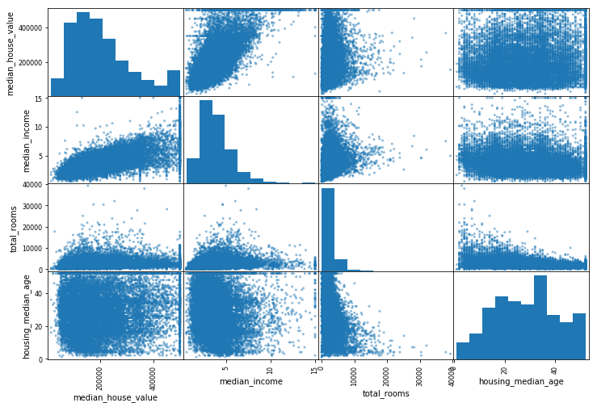

```python
attributes = ["median_house_value", "median_income", "total_rooms", "housing_median_age"]
scatter_matrix(housing[attributes], figsize=(12,8))
```

Graphically we can seee that median income correlates with value. Let's take a closer look at just that plot.

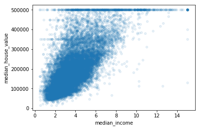

```python
housing.plot(kind="scatter", x="median_income", y="median_house_value", alpha=0.1)
```

The correlation is pretty strong and the points aren't super dispersed. There is clearly an annoying horizontal line at 500,000, but there are also some less obvious ones at 450k and 350k. Perhaps this is a quirk we'll want to deal with.

One other thing that we could want to do before we actually hand this data off to a ML algorithm is look at combinations of attributes. A simple example of this is that *number of rooms per district* most probably isn't useful unless you know how many houses there are. Probably *number of rooms per house* would be much better.

```python
housing["rooms_per_household"] = housing["total_rooms"] / housing["households"]
housing["bedrooms_per_room"] = housing["total_bedrooms"] / housing["total_rooms"]  # total number of bedrooms compared to rooms
housing["population_per_household"] = housing["population"] / housing["households"]
```

With these additional bits of data in the dataframe, let's look a the correlation matrix again.

```python
corr_matrix = housing.corr()
corr_matrix["median_house_value"].sort_values(ascending=False)
```

```
median_house_value          1.000000
median_income               0.687160
rooms_per_household         0.146285
total_rooms                 0.135097
housing_median_age          0.114110
households                  0.064506
total_bedrooms              0.047689
population_per_household   -0.021985
population                 -0.026920
longitude                  -0.047432
latitude                   -0.142724
bedrooms_per_room          -0.259984
Name: median_house_value, dtype: float64
```

bedrooms_per_room looks like it will end up being useful. Houses with a lower bedroom/room ratio tend to be more expensive. Rooms per household is also rather more correlated than some other attributes we previously had in our dataset

## Preparing the Data

First, let's revert back to a clean training set and separate the predictors abd the labels.

```python
housing = strat_train_set.drop("median_house_value", axis=1)
housing_labels = strat_train_set["median_house_value"].copy()
```

### Data Cleaning

As we noted above, missing features could cause us some problems. Specifically `total_bedrooms` is missing some values. We can fix this by

- Getting rid of the corresponding districts
- Getting rid of the whole attribute
- Setting the values to some value

We'll do the third option, with a builtin sklearn class.

```python
imputer = SimpleImputer(strategy="median")
```

Median can obviously only be computed on numerical attributes, so we should work on a copy of the data w/o the `ocean_proximity` data.

```python
housing_numerical = housing.drop("ocean_proximity", axis=1)
imputer.fit(housing_numerical)
```

```
SimpleImputer(copy=True, fill_value=None, missing_values=nan,
       strategy='median', verbose=0)
```

The imputer has computed the median of each attribute and stored its results. From what we've seen only `total_bedrooms` had missing data, but we should be prepared to handle missing data in any other attribute. So it's safest to apply the imputer to all numerical attributes.

```python
imputer.statistics_
```

```
array([-118.51  ,   34.26  ,   29.    , 2119.5   ,  433.    , 1164.    ,
        408.    ,    3.5409])
```

We can now use this imputer to transform the training set.

```python
X = imputer.transform(housing_numerical)
housing_tr = pd.DataFrame(X, columns=housing_numerical.columns)
housing_tr.info()
```

```
<class 'pandas.core.frame.DataFrame'>
RangeIndex: 16512 entries, 0 to 16511
Data columns (total 8 columns):
longitude             16512 non-null float64
latitude              16512 non-null float64
housing_median_age    16512 non-null float64
total_rooms           16512 non-null float64
total_bedrooms        16512 non-null float64
population            16512 non-null float64
households            16512 non-null float64
median_income         16512 non-null float64
dtypes: float64(8)
memory usage: 1.0 MB
```

No more missing data!

### Handling Test / Categorical

We left out the one textual field because we couldn't compute its median. Typically ML algorithms would rather work on numerical data than string data, so we'll convert these categories to numbers.

```python
housing_cat = housing[["ocean_proximity"]]
ordinal_encoder = OrdinalEncoder()
housing_cat_encoded = ordinal_encoder.fit_transform(housing_cat)
housing_cat_encoded[:10]
```

```
array([[0.],
       [0.],
       [4.],
       [1.],
       [0.],
       [1.],
       [0.],
       [1.],
       [0.],
       [0.]])
```

We can look at the categories.

```python
ordinal_encoder.categories_
```

```
[array(['<1H OCEAN', 'INLAND', 'ISLAND', 'NEAR BAY', 'NEAR OCEAN'],
       dtype=object)]
```

Doing things the way we just did might work fine if we're careful. However we've introduced a little bit of bias. Typically algorithms will assume that the value of the numbers in the categories are meaningful. For example it might assume that something with a category of 0 is closely related to something with a category of 1. But this is not the case.

Let's do one-hot encoding instead.

```python
cat_encoder = OneHotEncoder()
housing_cat_1hot= cat_encoder.fit_transform(housing_cat)
housing_cat_1hot.toarray()
```

```
array([[1., 0., 0., 0., 0.],
       [1., 0., 0., 0., 0.],
       [0., 0., 0., 0., 1.],
       ...,
       [0., 1., 0., 0., 0.],
       [1., 0., 0., 0., 0.],
       [0., 0., 0., 1., 0.]])
```

This is much better. Each category is now represented by a binary string where exactly one position of the string is 1 and the rest are 0.

### Custom Transforms

Without too much explanation here is a sklearn transformer that combines attributes as we discussed earlier.

```python
rooms_ix, bedrooms_ix, population_ix, household_ix = 3, 4, 5, 6

class CombinedAttributeAdder(BaseEstimator, TransformerMixin):

  def __init__(self, add_bedrooms_per_room=True):
    self.add_bedrooms_per_room = add_bedrooms_per_room

  def fit(self, X, y=None):
    return self

  def transform(self, X, y=None):
    rooms_per_household = X[:, rooms_ix] / X[:, household_ix]
    population_per_househould = X[:, population_ix] / X[:, household_ix]
    if self.add_bedrooms_per_room:
      bedrooms_per_room = X[:, bedrooms_ix] / X[:, rooms_ix]
      return np.c_[X, rooms_per_household, population_per_househould, bedrooms_per_room]
    else:
      return np.c_[X, rooms_per_household, population_per_househould]
```

Now that we have this, we have the ability to add these attributes as part of a pipline (which we'll talk about soon)

```python
attr_adder = CombinedAttributeAdder(add_bedrooms_per_room=False)
housing_extra_attribs = attr_adder.transform(housing.values)
housing_extra_attribs
```

```
array([[-121.89, 37.29, 38.0, ..., '<1H OCEAN', 4.625368731563422,
        2.094395280235988],
       [-121.93, 37.05, 14.0, ..., '<1H OCEAN', 6.008849557522124,
        2.7079646017699117],
       [-117.2, 32.77, 31.0, ..., 'NEAR OCEAN', 4.225108225108225,
        2.0259740259740258],
       ...,
       [-116.4, 34.09, 9.0, ..., 'INLAND', 6.34640522875817,
        2.742483660130719],
       [-118.01, 33.82, 31.0, ..., '<1H OCEAN', 5.50561797752809,
        3.808988764044944],
       [-122.45, 37.77, 52.0, ..., 'NEAR BAY', 4.843505477308295,
        1.9859154929577465]], dtype=object)
```

### Transformation Pipelines

We've got a few steps we need to get through as we clean our data and give it to a machine learning algorithm. Pipelines are a good way to run all these steps and in the correct order.

Here's a pipeline for our numerical attributes.

```python
num_pipeline = Pipeline([
    ('imputer', SimpleImputer(strategy="median")),
    ('attribs_adder', CombinedAttributeAdder()),
    ('std_scaler', StandardScaler())  # this makes sure the scales of all the numerical attributes are roughly the same
])
housing_num_tr = num_pipeline.fit_transform(housing_numerical)
```

Though, once-again, we're sort of ignored out categorical column. Sklearn has a way to deal with this as well.

```python
num_attribs = list(housing_numerical)
cat_attribs = ["ocean_proximity"]

full_pipeline = ColumnTransformer([
    ("num", num_pipeline, num_attribs),
    ("cat", OneHotEncoder(), cat_attribs)
])

housing_prepared = full_pipeline.fit_transform(housing)
```

That's it for now! Our data is ready to go into a model.

## Select and Train a Model

Basically we're just going to play around with some different models. Let's start out with linear regression.

```python
lin_reg = LinearRegression()
lin_reg.fit(housing_prepared, housing_labels)
```

```
LinearRegression(copy_X=True, fit_intercept=True, n_jobs=None,
         normalize=False)
```

Machine learning is easy. Let's see some predictions on the training set.

```python
some_data = housing.iloc[:5]
some_labels = housing_labels.iloc[:5]
some_data_prepared = full_pipeline.transform(some_data)
print ("Predictions:", lin_reg.predict(some_data_prepared))
print ("Labels:", list(some_labels))
```

```
Predictions: [210644.60459286 317768.80697211 210956.43331178  59218.98886849
 189747.55849879]
Labels: [286600.0, 340600.0, 196900.0, 46300.0, 254500.0]
```

Well. Obviously this isn't the most accurate thing in the world. The first prediction is off by 70,000. Let's measure the models RMSE on the whole training set.

```python
housing_predictions = lin_reg.predict(housing_prepared)
lin_mse = mean_squared_error(housing_labels, housing_predictions)
lin_rmse = np.sqrt(lin_mse)
lin_rmse
```

```
68628.19819848923
```

This is telling us that our typical prediction error is about 68k. That's not great. This is an example of underfitting and it means that either the features aren't sufficient to enable the prediction we want, or the model is not powerful enough. Let's try a more complex model.

```python
tree_reg = DecisionTreeRegressor()
tree_reg.fit(housing_prepared, housing_labels)

some_data = housing.iloc[:5]
some_labels = housing_labels.iloc[:5]
some_data_prepared = full_pipeline.transform(some_data)
print ("Predictions:", tree_reg.predict(some_data_prepared))
print ("Labels:", list(some_labels))
```

```
Predictions: [286600. 340600. 196900.  46300. 254500.]
Labels: [286600.0, 340600.0, 196900.0, 46300.0, 254500.0]
```

This time it got things exactly right on. Our model is either a genius or it's terrible. Let's look at the RMSE again.

```python
housing_predictions = tree_reg.predict(housing_prepared)
reg_mse = mean_squared_error(housing_labels, housing_predictions)
reg_rmse = np.sqrt(reg_mse)
reg_rmse
```

```
0.0
```

Oh shoot. It's horribly overfit.

### Cross Validation

We know our model has problems, it would be premature even to run it on the test set. Instead we should do cross validation. This splits our training set into essentially smaller sets and then we use those as train/test sets.

We'll use K-folds cross validation to randomly split our training data into 10 folds. It will evaluate our model 10 times, each time using 1 fold for evaluation and 9 for training.

```python
scores = cross_val_score(tree_reg, housing_prepared, housing_labels, scoring="neg_mean_squared_error", cv=10)
tree_rmse_scores = np.sqrt(-scores)
```

Let's look at these results.

```python
def display_scores(scores):
  print("Scores:", scores)
  print("Mean:", scores.mean())
  print("Std Deviation:", scores.std())

display_scores(tree_rmse_scores)
```

```
Scores: [70806.66273945 67040.55014937 71605.63344743 68699.66165745
 70821.23027783 76341.09422451 71617.75495557 70706.8314468
 75909.85620117 69426.2342445 ]
Mean: 71297.550934408
Std Deviation: 2758.583819222971
```

This makes our decision tree model look even worse than our linear model. Let's compute the same thing on the linear model

```python
lin_scores = cross_val_score(lin_reg, housing_prepared, housing_labels, scoring="neg_mean_squared_error", cv=10)
lin_rmse_scores = np.sqrt(-lin_scores)
display_scores(lin_rmse_scores)
```

```
Scores: [66782.73843989 66960.118071   70347.95244419 74739.57052552
 68031.13388938 71193.84183426 64969.63056405 68281.61137997
 71552.91566558 67665.10082067]
Mean: 69052.46136345083
Std Deviation: 2731.674001798344
```

This basically confirms the fact that the DecisionTree model is overfitting so badly that it is performing worse than the linear model.

Let's try one last model, a RandomForestRegressor.

```python
forest_reg = RandomForestRegressor(n_estimators=10)
forest_scores = cross_val_score(forest_reg, housing_prepared, housing_labels, scoring="neg_mean_squared_error", cv=10)
forest_rmse_scores = np.sqrt(-forest_scores)
display_scores(forest_rmse_scores)
```

```
Scores: [51743.60187493 50744.43364675 52066.59526259 55141.28651166
 52220.4219479  56274.78868471 51078.60089402 50174.39172792
 56230.94876232 51780.23508119]
Mean: 52745.53043939895
Std Deviation: 2154.2886631342694
```

It's our best yet. But still a bit gnarly.

## Fine tuning models

### Grid search

We *could* fiddle with our model hyperparameters manually until we find a great combination, but there are some built in methods to do this for us.

```python
param_grid = [
    {"n_estimators": [3, 10, 30], "max_features": [2, 4, 6, 8]},
    {"bootstrap": [False], "n_estimators": [3, 10], "max_features": [2, 3, 4]}
]
forest_reg = RandomForestRegressor()
grid_search = GridSearchCV(forest_reg, param_grid, cv=5, scoring='neg_mean_squared_error', return_train_score=True)
grid_search.fit(housing_prepared, housing_labels)
```

```
GridSearchCV(cv=5, error_score='raise-deprecating',
       estimator=RandomForestRegressor(bootstrap=True, criterion='mse', max_depth=None,
           max_features='auto', max_leaf_nodes=None,
           min_impurity_decrease=0.0, min_impurity_split=None,
           min_samples_leaf=1, min_samples_split=2,
           min_weight_fraction_leaf=0.0, n_estimators='warn', n_jobs=None,
           oob_score=False, random_state=None, verbose=0, warm_start=False),
       fit_params=None, iid='warn', n_jobs=None,
       param_grid=[{'n_estimators': [3, 10, 30], 'max_features': [2, 4, 6, 8]}, {'bootstrap': [False], 'n_estimators': [3, 10], 'max_features': [2, 3, 4]}],
       pre_dispatch='2*n_jobs', refit=True, return_train_score=True,
       scoring='neg_mean_squared_error', verbose=0)
```

```python
grid_search.best_params_
```

```
{'max_features': 8, 'n_estimators': 30}
```

We can see that this is our best combination of parameters. It probably makes sense to try some higher values because these are both parameter maxes.

We can directly access the best estimator.

```python
grid_search.best_estimator_
```

```
RandomForestRegressor(bootstrap=True, criterion='mse', max_depth=None,
           max_features=8, max_leaf_nodes=None, min_impurity_decrease=0.0,
           min_impurity_split=None, min_samples_leaf=1,
           min_samples_split=2, min_weight_fraction_leaf=0.0,
           n_estimators=30, n_jobs=None, oob_score=False,
           random_state=None, verbose=0, warm_start=False)
```

And we can also just get the evaluation scores from each estimator.

```python
cvres = grid_search.cv_results_
for mean_score, params in zip(cvres["mean_test_score"], cvres["params"]):
  print (np.sqrt(-mean_score), params)
```

```
64358.166906378276 {'max_features': 2, 'n_estimators': 3}
55505.68926594991 {'max_features': 2, 'n_estimators': 10}
52867.77704405329 {'max_features': 2, 'n_estimators': 30}
59851.53227554928 {'max_features': 4, 'n_estimators': 3}
52943.19295426325 {'max_features': 4, 'n_estimators': 10}
50665.91443912525 {'max_features': 4, 'n_estimators': 30}
57849.62933582565 {'max_features': 6, 'n_estimators': 3}
51879.152773778136 {'max_features': 6, 'n_estimators': 10}
50110.01490305376 {'max_features': 6, 'n_estimators': 30}
58274.444023906755 {'max_features': 8, 'n_estimators': 3}
51769.84091804701 {'max_features': 8, 'n_estimators': 10}
49873.27301976815 {'max_features': 8, 'n_estimators': 30}
62113.78447641043 {'bootstrap': False, 'max_features': 2, 'n_estimators': 3}
54294.80316987613 {'bootstrap': False, 'max_features': 2, 'n_estimators': 10}
59615.03581697931 {'bootstrap': False, 'max_features': 3, 'n_estimators': 3}
51998.852342465834 {'bootstrap': False, 'max_features': 3, 'n_estimators': 10}
59669.64591677953 {'bootstrap': False, 'max_features': 4, 'n_estimators': 3}
51684.0926596174 {'bootstrap': False, 'max_features': 4, 'n_estimators': 10}
```

### Analyze best models and errors

Sometimes by peaking into models we can get some good insight. For example, the random forest regressor can indicate the relevant importance of each attribute for making accurate predictions.

```python
feature_importances = grid_search.best_estimator_.feature_importances_
feature_importances
```

```
array([7.39782213e-02, 6.09132148e-02, 4.17323942e-02, 1.57258033e-02,
       1.48343803e-02, 1.55879466e-02, 1.37591135e-02, 3.55797663e-01,
       4.86483425e-02, 1.09895745e-01, 7.11770941e-02, 1.00183925e-02,
       1.62873795e-01, 8.95202503e-05, 2.05253334e-03, 2.91584041e-03])
```

```python
extra_attribs = ['rooms_per_hhold', 'pop_per_hhold', 'bedrooms_per_room']
cat_encoder = full_pipeline.named_transformers_["cat"]
cat_one_hot_attribs = list(cat_encoder.categories_[0])
attributes = num_attribs + extra_attribs + cat_one_hot_attribs
sorted(zip(feature_importances, attributes), reverse=True)
```

```
[(0.3557976631208742, 'median_income'),
 (0.16287379496812537, 'INLAND'),
 (0.10989574480238258, 'pop_per_hhold'),
 (0.07397822133778889, 'longitude'),
 (0.07117709407506317, 'bedrooms_per_room'),
 (0.060913214829988384, 'latitude'),
 (0.04864834253927721, 'rooms_per_hhold'),
 (0.04173239424613469, 'housing_median_age'),
 (0.015725803266898968, 'total_rooms'),
 (0.015587946553957328, 'population'),
 (0.014834380292383766, 'total_bedrooms'),
 (0.013759113516085953, 'households'),
 (0.010018392450838968, '<1H OCEAN'),
 (0.002915840410786705, 'NEAR OCEAN'),
 (0.0020525333390951747, 'NEAR BAY'),
 (8.952025031863204e-05, 'ISLAND')]
```

We can see that median_income remains most important, and really only one of the categories is useful. We could use this information to help give us a leg up on further optimization.

## Evaluate on the Test Set

If we're happy with our model its time to try it out on the test set. We should always resist the temptation to further hone the model to make it perform better on the test set.

```python
final_model = grid_search.best_estimator_
X_test = strat_test_set.drop("median_house_value", axis=1)
y_test = strat_test_set["median_house_value"].copy()

X_test_prepared = full_pipeline.transform(X_test)

final_predictions = final_model.predict(X_test_prepared)

final_mse = mean_squared_error(y_test, final_predictions)
final_rmse = np.sqrt(final_mse)
final_rmse
```

```
47943.43427320574
```